## 1. Introduction

The main purpose of this assignment is to come up with a suitable linear regression model to forecast the number of unleaded gasoline sale(in 1000 m3) in a given quarter(UGS) for four quarters in the year 2007, by making use of the quarterly UGS data obtained between years 2000-2006. In order to derive an adequate and reasonable linear regression model, several steps were taken. First of all, time series of UGS and its autocorrelation function were plotted and several relevant comments were made. Then, various components such as trend and seasonality were chosen as factors affecting the number of UGS. In the third step, useful independent variables were chosen via correlation analyses to further improve the linear regression model. Finally, after constructing the final linear regression model, the next four quarters were forecasted.

In the remaining part of this assignment, some variables will be given with their abbreviations in order to make this report seem as little crowded as possible. Abbreviations and their full forms are given below.

**UGS:** Unleaded gasoline sale(in 1000 m^3) in a given quarter

**NLPG:** Number of LPG vehicles

**RNUV:** An index indicating the rate of new unleaded gasoline using vehicles being added to the traffic in a quarter

**PU:** Average price (adjusted with an index) of a liter of unleaded gasoline in a quarter

**PG:** Average price (adjusted with an index) of a liter of diesel gasoline in a quarter

**NUGV:** Number of unleaded gasoline using vehicles in the traffic

**NDGV:** Number of diesel gasoline using vehicles in the traffic (per 1000 people)

**GNPA:** Agriculture component of Gross National Product (adjusted with an index)

**GNPC:** Commerce component of Gross National Product (adjusted with an index)

**GNP:** Grand total for GNP (agriculture, commerce and other components total)

## 2. Plotting the Time Series and ACF

The number of unleaded gasoline sales in Turkey with respect to time can be plotted as in the following:

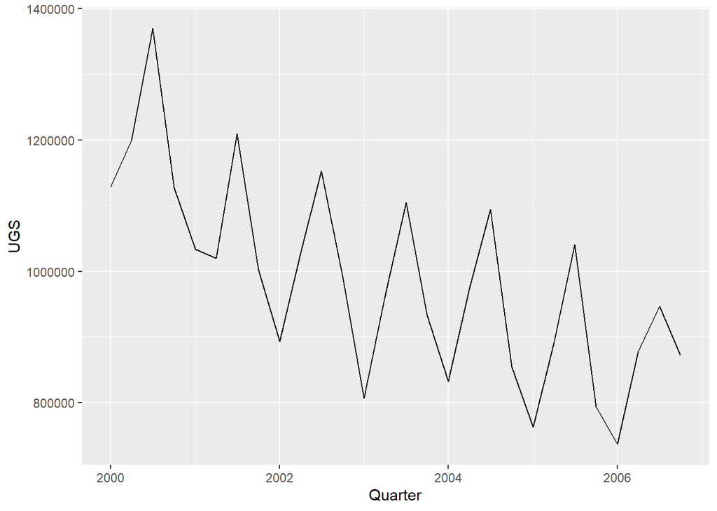

```r
library(forecast)
library(xts)
library(zoo)
library(ggplot2)
library(data.table)
library(roll)
library(GGally)

hw2data <- read.csv("C:/Users/lenovo/Desktop/IE360_Spring22_HW2_data (1).csv",colClasses  = c("character", "numeric", "numeric", "numeric", "numeric", "numeric", "numeric","numeric","numeric","numeric","numeric"))
colnames(hw2data) <- c("Quarter","UGS","RNUV","NLPG","PU","PG","NUGV","NDGV","GNPA","GNPC","GNP")
mydata <- hw2data[c(1:28),]
mydata_test <- hw2data[c(29:32),]
mydata <- data.table(mydata)

mydata$Quarter=as.Date(as.yearqtr(mydata$Quarter, format = "%Y_Q%q"))

ggplot(mydata,aes(x=Quarter)) +
  geom_line(aes(y=UGS, group = 1))
```

First of all, after observing the time series plot, it can be concluded that the data shows an overall negative trend, meaning the data values seem to be climbing down with white noise. To account for the trend, it is logical to include a trend component in the model. Negative trend essentially means that data mean decreases over time, which indicates that the data mean is non-stationary. On the other hand, when we look at the variance, it doesn’t change drastically over the specified time period, it almost stays the same. Due to this, it can be said that data variance is stationary. However, the overall time series is not stationary since its mean is clearly non-stationary. In order to back this claim, rolling mean and variance plots can be given.

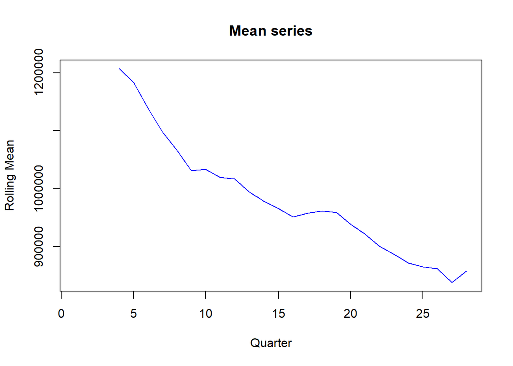

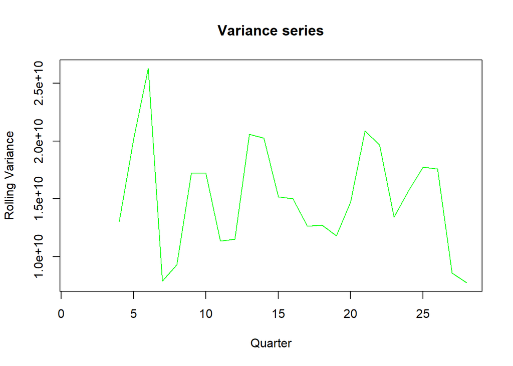

As it has been stated before, mean decreases as quarters increase, hence it is not stationary. But variance can be regarded as stationary, since it mostly stays the same throughout time.

Moreover, in the first quarters of each year, UGS data is almost always low when compared to the other three quarters of that year. This indicates seasonality in our data, and it is logical to include this factor using a quarter variable.

In addition, the corresponding autocorrelation function can be plotted as follows:

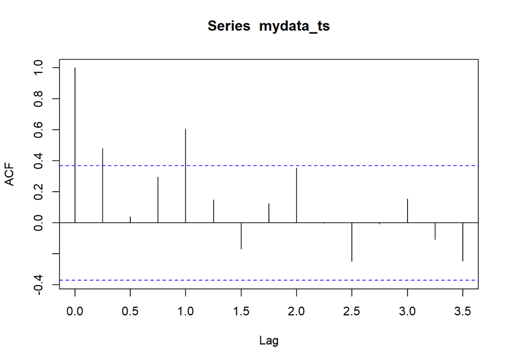

Autocorrelation function is an indicator of seasonality that may exist in time series data. It can be seen that there is a positive correlation in lag 1 and lag 4. Correlation in lag 4 supports the seasonality claim made above, which stated that this time series data has a seasonality component. Since the correlation in lag 1 is undesirable, a lagged variable can be added to the model.